# Cluster purity & item-prototype distances for labels alignment

Load helper functions and libraries

# Purity of clusters by condition

Purity is measured as the proportion of A and B items within a cluster, taking into account whether that clusters contains a prototype item (or both).

## Visualization of purity across conditions

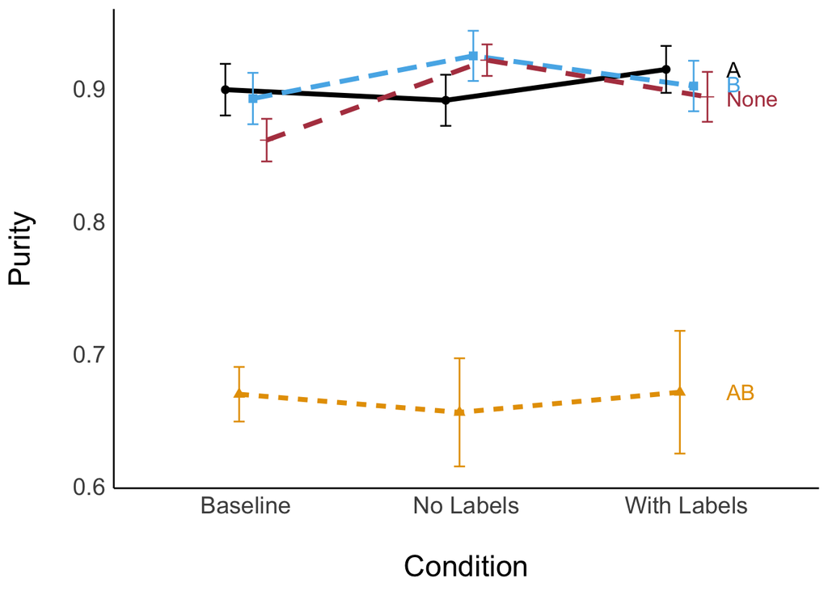

Not surprisingly, purity is inversely correlated with cluster-size. The bigger the cluster, the less pure

```
##               purity  num_items
## purity     1.0000000 -0.3301847
## num_items -0.3301847  1.0000000
```

But interestingly, the correlation is smallest for the label condition

```
## # A tibble: 3 × 2
##   Condition   purity_size_correlation
##   <chr>                         <dbl>
## 1 Baseline                     -0.309
## 2 No Labels                    -0.463
## 3 With Labels                  -0.224
```

Model the interaction between number of items in a cluster by label condition: We see only a significant effect of number of items (more items = lower purity).

```
## Linear mixed model fit by REML. t-tests use Satterthwaite's method [
## lmerModLmerTest]
## Formula: purity ~ num_items * Condition + (1 | subjCode)
##    Data: .
##
## REML criterion at convergence: -411.4
##
## Scaled residuals:
##     Min      1Q  Median      3Q     Max
## -2.8730 -0.4758  0.2308  0.5905  1.6976
##
## Random effects:
##  Groups   Name        Variance Std.Dev.
##  subjCode (Intercept) 0.009323 0.09656
##  Residual             0.017181 0.13108
## Number of obs: 479, groups:  subjCode, 129
##
## Fixed effects:
##                                  Estimate Std. Error         df t value
## (Intercept)                      0.930343   0.032253 254.849144  28.845
## num_items                       -0.015987   0.004818 452.994725  -3.318
## ConditionNo Labels               0.060604   0.043453 229.085669   1.395
## ConditionWith Labels             0.007969   0.050783 244.242048   0.157
## num_items:ConditionNo Labels    -0.003407   0.006232 451.194203  -0.547
## num_items:ConditionWith Labels   0.006197   0.006701 427.273237   0.925
##                                Pr(>|t|)
## (Intercept)                     < 2e-16 ***
## num_items                       0.00098 ***
## ConditionNo Labels              0.16446
## ConditionWith Labels            0.87543
## num_items:ConditionNo Labels    0.58490
## num_items:ConditionWith Labels  0.35562
## ---
## Signif. codes:  0 '***' 0.001 '**' 0.01 '*' 0.05 '.' 0.1 ' ' 1
##
## Correlation of Fixed Effects:
##             (Intr) nm_tms CndtNL CndtWL n_:CNL
## num_items   -0.836
## CondtnNLbls -0.742  0.620
## CndtnWthLbl -0.635  0.531  0.471
## nm_tms:CnNL  0.646 -0.773 -0.811 -0.410
## nm_tms:CnWL  0.601 -0.719 -0.446 -0.847  0.556
```

Use logistic regression with cluster_size as weights to see if there are differences in purity between the conditions. First the descriptives:

```
## # A tibble: 3 × 3
##   Condition   avg_purity sd_cond
##   <chr>            <dbl>   <dbl>
## 1 Baseline         0.855   0.174
## 2 No Labels        0.903   0.159
## 3 With Labels      0.877   0.170
```

…with labels is in between the others. Let’s use baseline as the reference level and see if there are effects of condition. No significant effects

```
## Generalized linear mixed model fit by maximum likelihood (Laplace
##   Approximation) [glmerMod]
##  Family: binomial  ( logit )
## Formula: purity ~ relevel(as.factor(Condition), ref = "Baseline") + (1 |
##     subjCode)
##    Data: .
## Weights: num_items
##
##      AIC      BIC   logLik deviance df.resid
##    977.4    994.1   -484.7    969.4      475
##
## Scaled residuals:
##     Min      1Q  Median      3Q     Max
## -2.4641 -0.4049  0.3918  0.6080  1.1599
##
## Random effects:
##  Groups   Name        Variance Std.Dev.
##  subjCode (Intercept) 1.128    1.062
## Number of obs: 479, groups:  subjCode, 129
##
## Fixed effects:
##                                                            Estimate Std. Error
## (Intercept)                                                  1.8750     0.1935
## relevel(as.factor(Condition), ref = "Baseline")No Labels     0.2976     0.2774
## relevel(as.factor(Condition), ref = "Baseline")With Labels   0.2843     0.2799
##                                                            z value Pr(>|z|)
## (Intercept)                                                  9.690   <2e-16 ***
## relevel(as.factor(Condition), ref = "Baseline")No Labels     1.073    0.283
## relevel(as.factor(Condition), ref = "Baseline")With Labels   1.016    0.310
## ---
## Signif. codes:  0 '***' 0.001 '**' 0.01 '*' 0.05 '.' 0.1 ' ' 1
##
## Correlation of Fixed Effects:
##                 (Intr) r(.(C),r="B")NL
## r(.(C),r="B")NL -0.662
## r(.(C),r="B")WL -0.661  0.467
```

# Distance between prototype and item by distortion level and condition

Distance is measured as the Euclidean distance (x,y) between items in the sorts. We are most interested in whether the different levels of shape distortion affected how likely participants were to place items close to the prototype, and whether condition 9baseline, no labels or with labels) interacted with any effect of distortion.

## Visualization (raw distance)

```
## Automatically converting the following non-factors to factors: Condition
```

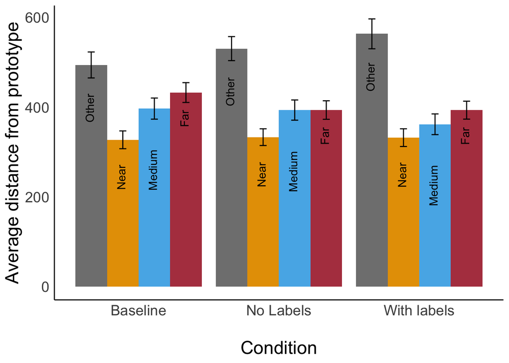

## Visualization (log of distance by distortion adjusted by ‘other’)

To get the log difference adjusted by other, for each participant we calculate:  
1. near = log(abs(average distance between prototype and within-category ‘near’ items/distance between prototype and between category items))  
2. medium = log(abs(average distance between prototype and within-category ‘medium’ items/distance between prototype and between category items))  
3. far = log(abs(average distance between prototype and within-category ‘far’ items/distance between prototype and between category items))

```
## Automatically converting the following non-factors to factors: Condition
```

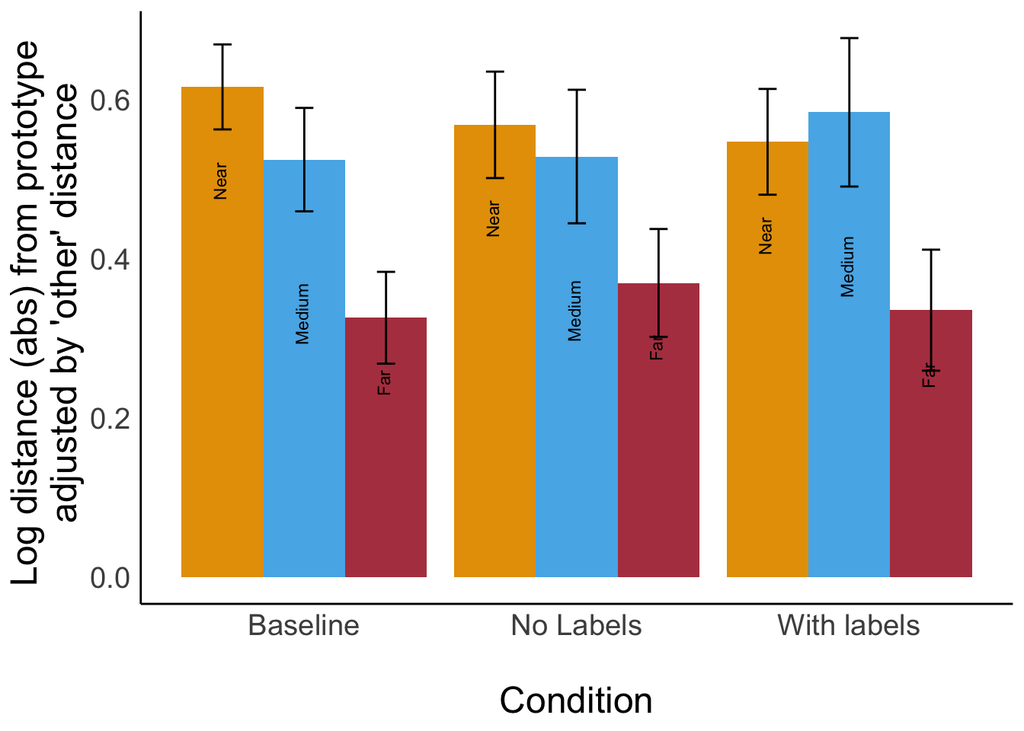

Now model the log distance across conditions

Full model

More likely to put closer items to prototype, than far items, makes sense. With labels has overall smaller (within-category) distances than baseline, but condition doesn’t appear to interact significantly with distance from the prototype.

```r
distance_log %>%
    lmer(log_dist~log_distance_type*Condition+(1|participant),data=.) %>% summary
```

```
## Linear mixed model fit by REML. t-tests use Satterthwaite's method [
## lmerModLmerTest]
## Formula: log_dist ~ log_distance_type * Condition + (1 | participant)
##    Data: .
##
## REML criterion at convergence: 778
##
## Scaled residuals:
##     Min      1Q  Median      3Q     Max
## -3.8724 -0.4483  0.0344  0.5132  2.9770
##
## Random effects:
##  Groups      Name        Variance Std.Dev.
##  participant (Intercept) 0.4663   0.6829
##  Residual                0.2138   0.4623
## Number of obs: 387, groups:  participant, 129
##
## Fixed effects:
##                                                         Estimate Std. Error
## (Intercept)                                             -0.16447    0.12293
## log_distance_typelog_proto_medium                       -0.19883    0.09747
## log_distance_typelog_proto_near                         -0.29027    0.09747
## ConditionNo Labels                                      -0.19303    0.17586
## ConditionWith labels                                    -0.36103    0.17804
## log_distance_typelog_proto_medium:ConditionNo Labels     0.03989    0.13944
## log_distance_typelog_proto_near:ConditionNo Labels       0.09149    0.13944
## log_distance_typelog_proto_medium:ConditionWith labels  -0.04999    0.14117
## log_distance_typelog_proto_near:ConditionWith labels     0.07855    0.14117
##                                                               df t value
## (Intercept)                                            194.81545  -1.338
## log_distance_typelog_proto_medium                      252.00000  -2.040
## log_distance_typelog_proto_near                        252.00000  -2.978
## ConditionNo Labels                                     194.81545  -1.098
## ConditionWith labels                                   194.81545  -2.028
## log_distance_typelog_proto_medium:ConditionNo Labels   252.00000   0.286
## log_distance_typelog_proto_near:ConditionNo Labels     252.00000   0.656
## log_distance_typelog_proto_medium:ConditionWith labels 252.00000  -0.354
## log_distance_typelog_proto_near:ConditionWith labels   252.00000   0.556
##                                                        Pr(>|t|)
## (Intercept)                                             0.18248
```

[output cut: 24 more lines]

```
## CondtnNLbls
## CndtnWthlbl               0.483
## lg_dstnc_typlg_prt_m:CNL -0.396 -0.191
## lg_dstnc_typlg_prt_n:CNL -0.396 -0.191  0.500
## lg_dstnc_typlg_prt_m:CWl -0.191 -0.396  0.483
## lg_dstnc_typlg_prt_n:CWl -0.191 -0.396  0.241
##                          lg_dstnc_typlg_prt_n:CNL lg_dstnc_typlg_prt_m:CWl
## lg_dstnc_typlg_prt_m
## lg_dstnc_typlg_prt_n
## CondtnNLbls
## CndtnWthlbl
## lg_dstnc_typlg_prt_m:CNL
## lg_dstnc_typlg_prt_n:CNL
## lg_dstnc_typlg_prt_m:CWl  0.241
## lg_dstnc_typlg_prt_n:CWl  0.483                    0.500
```

No labels vs. with labels

No labels and with labels do not significantly differ

```r
distance_log %>% filter(Condition != "Baseline") %>%
    lmer(log_dist~log_distance_type*Condition+(1|participant),data=.) %>% summary
```

```
## Linear mixed model fit by REML. t-tests use Satterthwaite's method [
## lmerModLmerTest]
## Formula: log_dist ~ log_distance_type * Condition + (1 | participant)
##    Data: .
##
## REML criterion at convergence: 534
##
## Scaled residuals:
##     Min      1Q  Median      3Q     Max
## -3.6275 -0.4390  0.0486  0.4634  2.7511
##
## Random effects:
##  Groups      Name        Variance Std.Dev.
##  participant (Intercept) 0.4915   0.7011
##  Residual                0.2446   0.4946
## Number of obs: 252, groups:  participant, 84
##
## Fixed effects:
##                                                         Estimate Std. Error
## (Intercept)                                             -0.35751    0.13084
## log_distance_typelog_proto_medium                       -0.15894    0.10666
## log_distance_typelog_proto_near                         -0.19878    0.10666
## ConditionWith labels                                    -0.16800    0.18727
## log_distance_typelog_proto_medium:ConditionWith labels  -0.08989    0.15267
## log_distance_typelog_proto_near:ConditionWith labels    -0.01293    0.15267
##                                                               df t value
## (Intercept)                                            130.04557  -2.732
## log_distance_typelog_proto_medium                      164.00000  -1.490
## log_distance_typelog_proto_near                        164.00000  -1.864
## ConditionWith labels                                   130.04557  -0.897
## log_distance_typelog_proto_medium:ConditionWith labels 164.00000  -0.589
## log_distance_typelog_proto_near:ConditionWith labels   164.00000  -0.085
##                                                        Pr(>|t|)
## (Intercept)                                             0.00716 **
## log_distance_typelog_proto_medium                       0.13811
## log_distance_typelog_proto_near                         0.06416 .
## ConditionWith labels                                    0.37133
## log_distance_typelog_proto_medium:ConditionWith labels  0.55683
## log_distance_typelog_proto_near:ConditionWith labels    0.93259
## ---
## Signif. codes:  0 '***' 0.001 '**' 0.01 '*' 0.05 '.' 0.1 ' ' 1
##
## Correlation of Fixed Effects:
##                          (Intr) lg_dstnc_typlg_prt_m lg_dstnc_typlg_prt_n
## lg_dstnc_typlg_prt_m     -0.408
## lg_dstnc_typlg_prt_n     -0.408  0.500
## CndtnWthlbl              -0.699  0.285                0.285
## lg_dstnc_typlg_prt_m:CWl  0.285 -0.699               -0.349
## lg_dstnc_typlg_prt_n:CWl  0.285 -0.349               -0.699
##                          CndtWl lg_dstnc_typlg_prt_m:CWl
## lg_dstnc_typlg_prt_m
## lg_dstnc_typlg_prt_n
## CndtnWthlbl
## lg_dstnc_typlg_prt_m:CWl -0.408
## lg_dstnc_typlg_prt_n:CWl -0.408  0.500
```